# Probability in a Nutshell

3 Nov 2014

## What is probabilty?

Probability theory is the mathematical abstraction formalizing the mathematics of uncertain events

In Southern Chile sheep can be predated by Culpeo foxes, pumas or stray dogs:

Predation by puma is an **event**

to be predated or not is an **outcome** of the above event

**sample space**: the set of all possible outcomes of a specific event: ex. sheep predated by fox, puma, dog or the probability of a coin being flipped head or tail

## What is the probabilty that flipping a coin it comes out "head"?

One common way to interpret *probability* is as the

*long run frequency of an outcome in a series of repeated trials*

Which means: the probability that the coin comes out head is equal to the proportion of times it comes out "head", repeating the coin flipping experiment infinite times (frequency interpretation of probability).

## Running proportion of heads flipping a coin

trial:

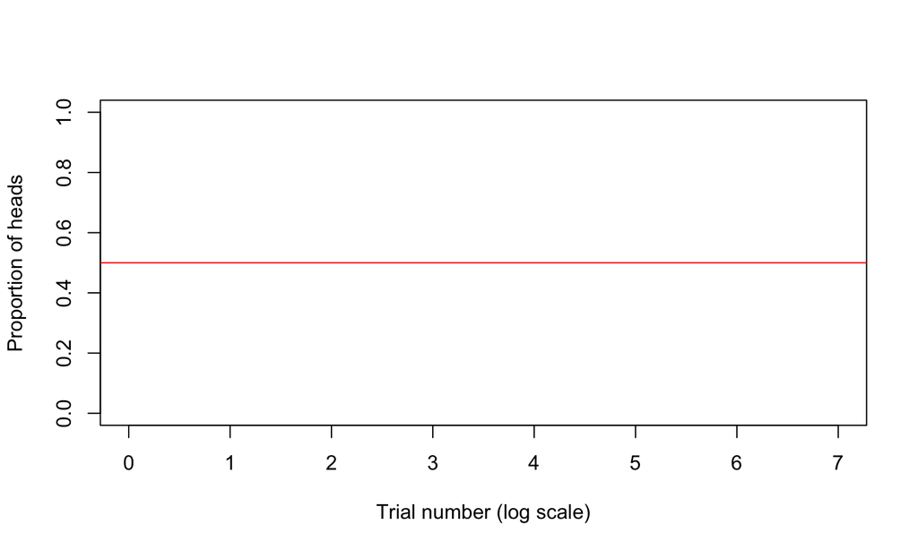

## Running proportion of heads flipping a coin

trial: 1

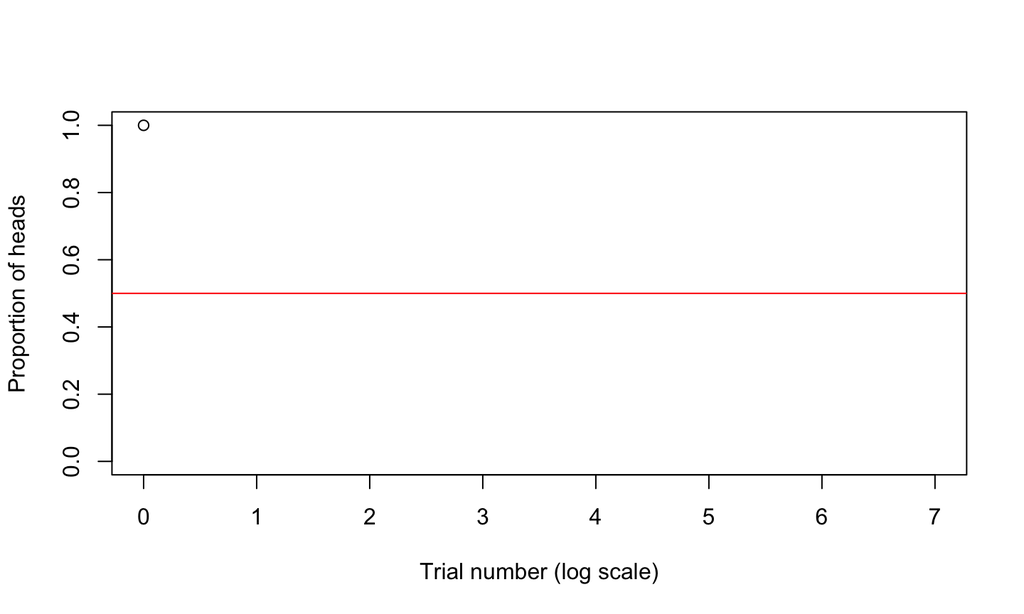

## Running proportion of heads flipping a coin

trial: 2

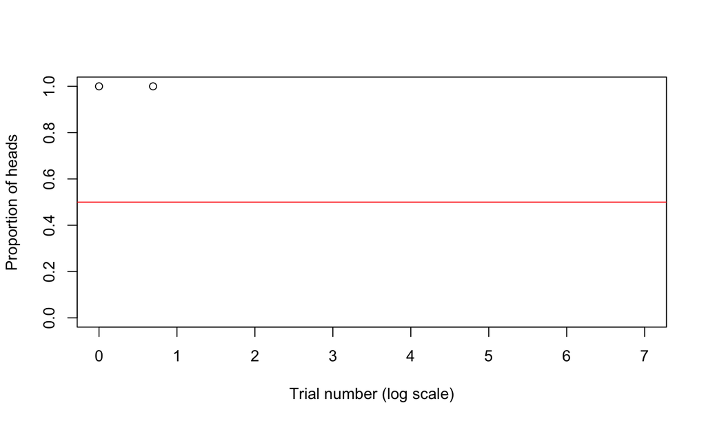

## Running proportion of heads flipping a coin

trial:3

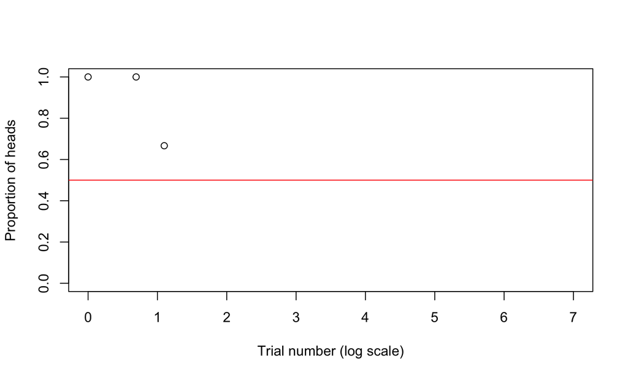

## Running proportion of heads flipping a coin

trial:4

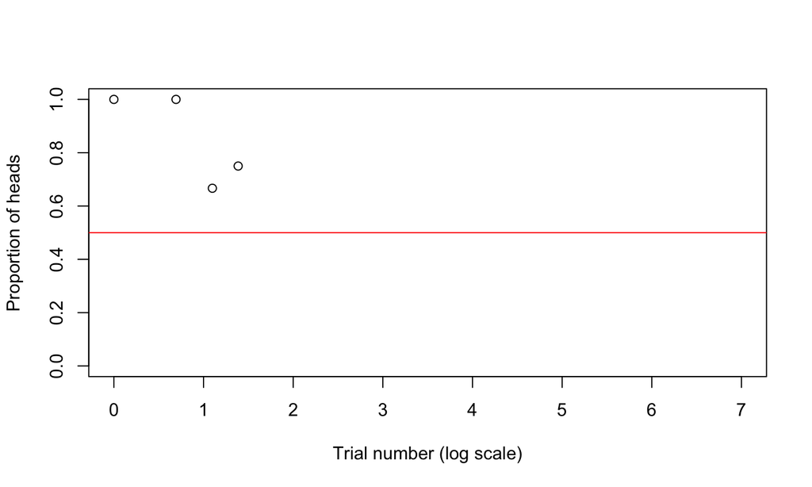

## Running proportion of heads flipping a coin

trial:5

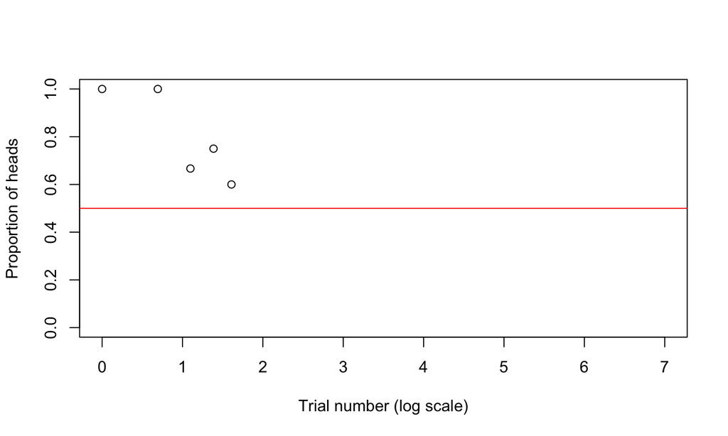

## Running proportion of heads flipping a coin

trial:6

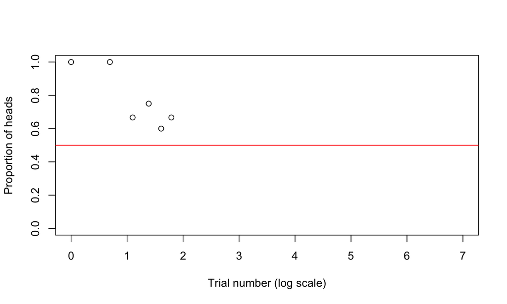

## Running proportion of heads flipping a coin

trial:7

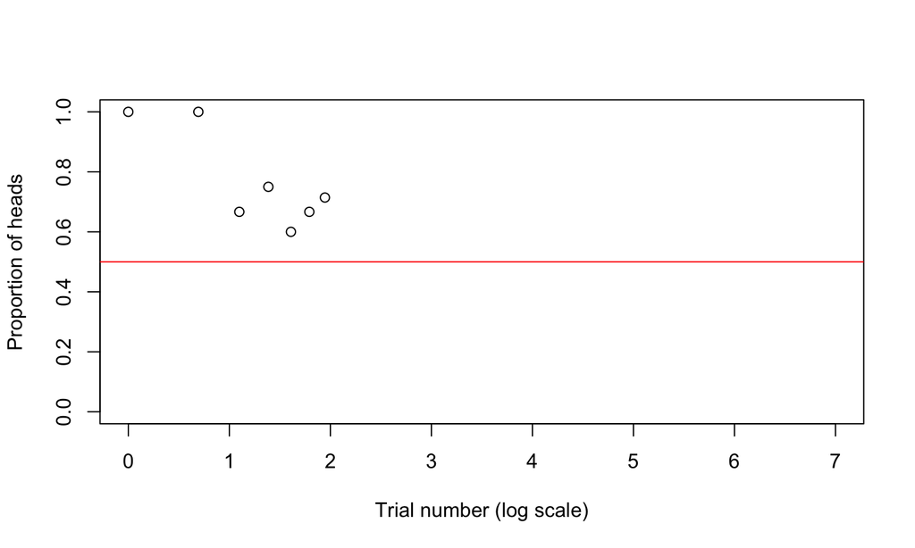

## Running proportion of heads flipping a coin

trial:8

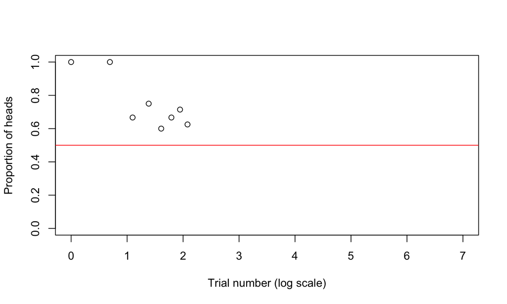

## Running proportion of heads flipping a coin

trial:9

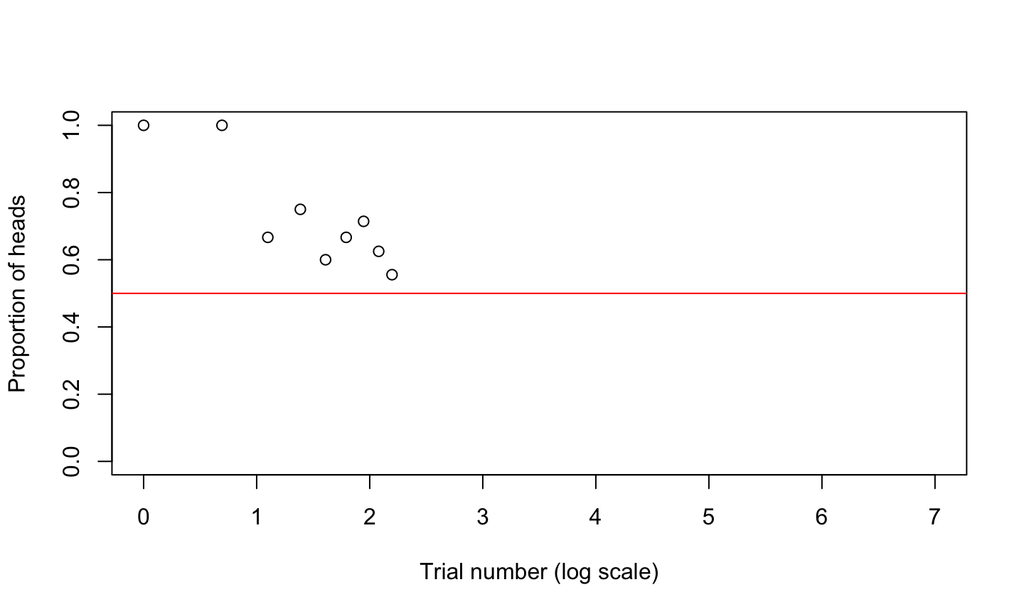

## Running proportion of heads flipping a coin

trial:10

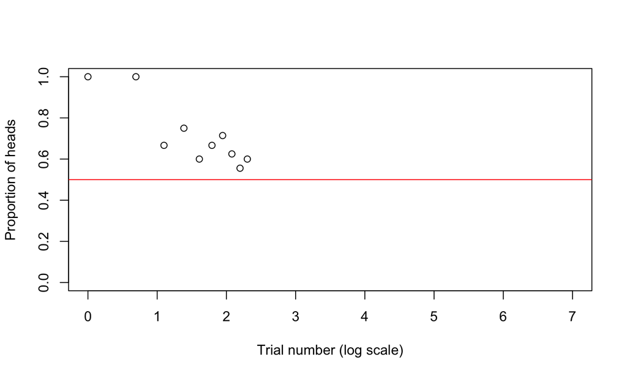

## Running proportion of heads flipping a coin

trial:50

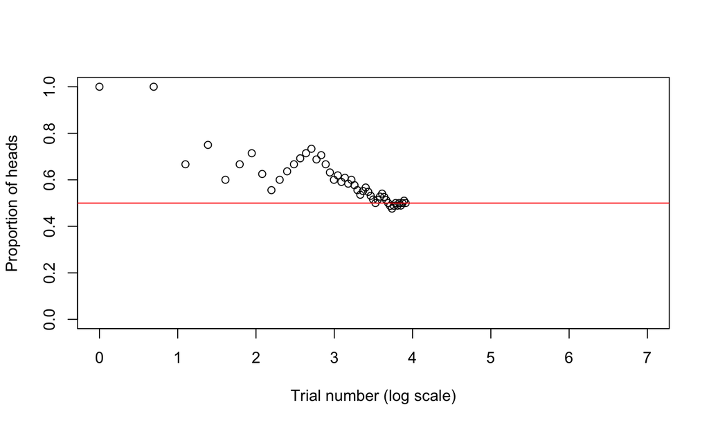

## Running proportion of heads flipping a coin

trial:100

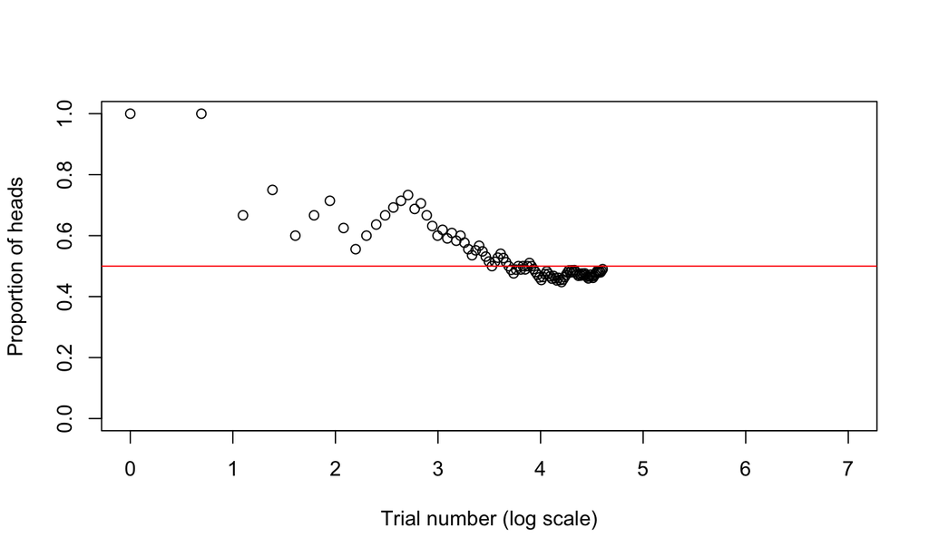

## Running proportion of heads flipping a coin

trial:500

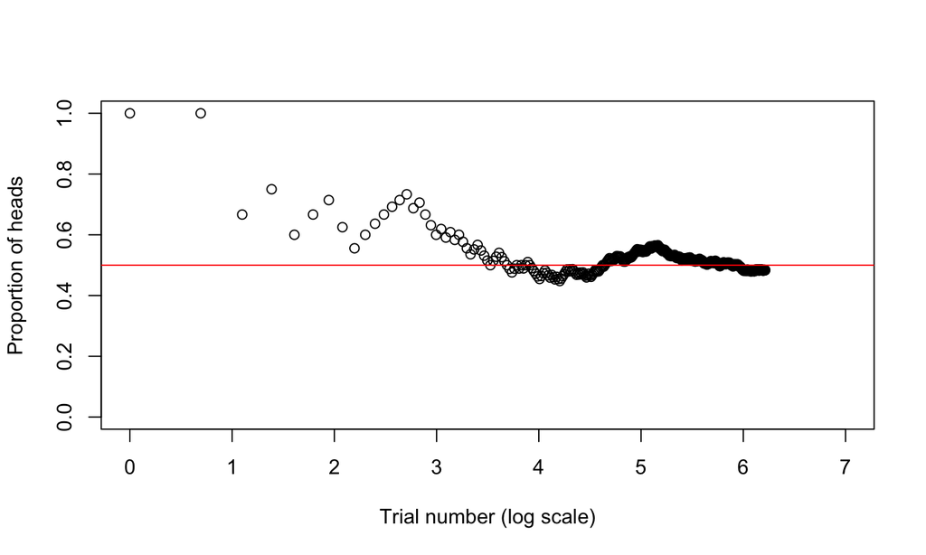

## Basic probability laws

Mathematical laws ruling the the combination of *events*

**Mutually exclusive events**

Predation by Culpeo fox or by puma are mutually exclusive events (a single sheep can not be predated by both)

**Sheep Predation Probabilities by different predators**

| Symbol | Species | Probability |
| --- | --- | --- |
| F | Fox | 0.026 |
| P | Puma | 0.010 |
| D | Dog | 0.063 |

## Basic probability laws

What is the probability to be predated by a fox (F) *or* by a puma (P)?

\(P(F \cup P) = P(F)+P(P)\)

The \(\cup\) symbol means 'Union'

\(P(Fox \ or \ Puma) = 0.026+0.010\)

\(P(Fox \ or \ Puma) = 0.036\)

What is the probability to be predated by any predator?

\(P(Fox \ or \ Puma \ or \ Dog) = P(Fox)+P(Puma)+P(Dog)\)

\(P(Fox \ or \ Puma \ or \ Dog) = 0.026+0.010+0.063 = 0.099\)

## Non-mutually exclusive events

Sheep can be white or black  
The color (C) of the sheep is the *event* and black or white are the two possible *outcomes*

What is the probabilty that a sheep is black?

Let's say it's \(P(C_{black}) = 0.2\)

> **The probabilities of all the possible outcomes sum up to 1**

What is the probabilty that a sheep is white?

\(P(C_{white}) = 1 - P(C_{black}) = 0.8\)

## Non-mutually exclusive events

What is the probabilty that a sheep is of a particular color **or** is predated by a stray dog?

\(P(C \cup D) = P(C)+P(D)-P(C \cap D)\)

\(P(C \cap D)\) is the *joint* probabilty (intersection) of being both of a particular color and being predated by a stray dog. If the color of the sheep and predation by dogs are *independent* events (i.e. knowing about one event does not provide information about the other) then:

\(P(C \cap D) = P(C)P(D)\)

and thus

Probability of being Black or Predated by Dog = 0.2+0.063-0.2x0.063 =0.2504

Probability of being White or Predated by Dog = 0.8+0.063-0.8x0.063 =0.8126

## Conditional probability

Let's say we visit 100 alpine lakes and record if there is the presence of alien brook trout (*Salvelinus fontinalis*) and of common frogs (*Rana temporaria*):

Event F = Frog detection: probability to detect a frog during a visit  
Event T = Trout presence: probability that a lake is inhabited by alien brook trout

| / | Trouts | no Trouts | Total |
| --- | --- | --- | --- |
| Frogs | 5 | 35 | 40 |
| No Frogs | 45 | 15 | 60 |
| Total | 50 | 50 | 100 |

\(P(T) = 50/100 = 0.5\)  
\(P(F) = 40/100 = 0.4\) \(P(F \cap T) = 5/100 = 0.05\)

## Conditional Probability

What is the probability to find common frogs (*Rana temporaria*) in Alpine lakes in which there is the presence of brook trout?

\(P(F|T) = \frac{P(F \cap T)}{P(T)}\)

\(P(F|T) = 0.05/0.5 = 0.1\)

So… what is the conditional probability to find frogs in lakes without brook trout?

\(P(F|T_{no}) = 0.35/0.5 = 0.7\)

## Bayes' Theorem

if  
\(P(A|B) = \frac{P(A \cap B)}{P(B)}\)

we can also write  
\(P(A \cap B) = P(A|B)P(B)\)

and  
\(P(B \cap A) = P(B|A)P(A)\)

and because  
\(P(A \cap B) = P(B \cap B)\)  
\(P(B|A)P(A) = P(A|B)P(B)\)

re-arranging we get the **Bayes' Theorem**:

\[\large{P(B|A) = \frac{P(A|B)P(B)}{P(A)}}\]

## Bayes' Theorem

What is the probability that there are brook trout in a lake if I found frogs?

\(P(T|F) = \frac{P(F|T)P(T)}{P(F)}\)

\(P(T|F) = \frac{0.1 \times 0.5}{0.4} = 0.125\)